# High Myopia and Emmetropia: Exploratory Lens Expression Analysis

# 1 Overview

I compare expression in three high-myopia and three emmetropic human lens epithelial samples from NCBI GEO GSE136701. The aim is to explore sample relationships and test for differences between groups. This notebook reruns the existing R scripts; it does not rely on objects in the RStudio Global Environment. An internet connection is required for the GEO downloads.

This is an exploratory analysis of older adult surgical samples, not a clinical prediction tool. Probe-level results are not automatically gene-level findings.

# 2 Import the dataset

The import script downloads the GEO Series Matrix to a temporary file, then extracts expression values and metadata. Platform annotation is not downloaded.

```r
run_script("code/myopic and emmetropic human eye.R")
```

```
##                         title
## GSM4055612 lens_high myopia_1
## GSM4055613  lens_emmetropia_1
## GSM4055614 lens_high myopia_2
## GSM4055615  lens_emmetropia_2
## GSM4055616  lens_emmetropia_3
## GSM4055617 lens_high myopia_3
##                                               source_name_ch1
## GSM4055612 lens epithelium, high myopia, axial length 29.98mm
## GSM4055613  lens epithelium, emmetropia, axial length 22.30mm
## GSM4055614 lens epithelium, high myopia, axial length 31.54mm
## GSM4055615  lens epithelium, emmetropia, axial length 23.44mm
## GSM4055616  lens epithelium, emmetropia, axial length 22.99mm
## GSM4055617 lens epithelium, high myopia, axial length 34.74mm
##                                       characteristics_ch1 characteristics_ch1.1
## GSM4055612 tissue: Anterior lens epithelial cell membrane        gender: Female
## GSM4055613 tissue: Anterior lens epithelial cell membrane          gender: Male
## GSM4055614 tissue: Anterior lens epithelial cell membrane          gender: Male
## GSM4055615 tissue: Anterior lens epithelial cell membrane        gender: Female
## GSM4055616 tissue: Anterior lens epithelial cell membrane        gender: Female
## GSM4055617 tissue: Anterior lens epithelial cell membrane          gender: Male
##            characteristics_ch1.2  characteristics_ch1.3
## GSM4055612           age: 53 yrs diagnosis: High myopia
## GSM4055613           age: 63 yrs  diagnosis: Emmetropia
## GSM4055614           age: 68 yrs diagnosis: High myopia
## GSM4055615           age: 68 yrs  diagnosis: Emmetropia
## GSM4055616           age: 60 yrs  diagnosis: Emmetropia
## GSM4055617           age: 55 yrs diagnosis: High myopia
```

```r
knitr::kable(data.frame(
  Measurement = c("Probes", "Samples", "Missing values", "Infinite values"),
  Value = c(nrow(expr), ncol(expr), sum(is.na(expr)), sum(is.infinite(expr)))
))
```

| Measurement | Value |
| --- | --- |
| Probes | 54675 |
| Samples | 6 |
| Missing values | 0 |
| Infinite values | 0 |

```r
annotation(eset)
```

```
## [1] "GPL570"
```

```r
summary(as.vector(expr))
```

```
##    Min. 1st Qu.  Median    Mean 3rd Qu.    Max.
##  -2.640   4.873   6.788   6.860   8.982  16.539
```

# 3 Sample information and quality checks

Groups are assigned from recorded diagnoses, not assumed sample order. The quality-check script verifies alignment, checks finite values, and exports the sample table. The participants are aged 53–68 years. Emmetropia is the recorded control diagnosis, not a claim that all controls are otherwise healthy.

```r
run_script("code/02_quality_checks.R")
```

```
##    Sample_ID       Group Age
## 1 GSM4055612 High myopia  53
## 2 GSM4055613  Emmetropia  63
## 3 GSM4055614 High myopia  68
## 4 GSM4055615  Emmetropia  68
## 5 GSM4055616  Emmetropia  60
## 6 GSM4055617 High myopia  55
## group
##  Emmetropia High myopia
##           3           3
##                                                                                                                  data_processing
## GSM4055612 Raw data were normalized by MAS 5.0 algorithm, GeneSpring Software12.6.1 (Agilent Technologies, Santa Clara, CA, US).
```

```r
knitr::kable(sample_table, caption = "Verified sample identities, groups and ages")
```

Verified sample identities, groups and ages

| Sample_ID | Group | Age |
| --- | --- | --- |
| GSM4055612 | High myopia | 53 |
| GSM4055613 | Emmetropia | 63 |
| GSM4055614 | High myopia | 68 |
| GSM4055615 | Emmetropia | 68 |
| GSM4055616 | Emmetropia | 60 |
| GSM4055617 | High myopia | 55 |

# 4 Expression-scale verification

GEO describes MAS 5.0 normalisation in GeneSpring 12.6.1 but does not explicitly identify the transformation scale in the inspected descriptions. The next script compares one submitted sample record against the matrix.

```r
run_script("code/check_expression_scale.R")
```

```
##   Column             Description
## 1                       ID_REF =
## 2  VALUE MAS5.0 signal intensity
## 3                     ABS call =
## [1] "Raw data were normalized by MAS 5.0 algorithm, GeneSpring Software12.6.1 (Agilent Technologies, Santa Clara, CA, US)."
##               Probe Submitted    Matrix
## 1007_s_at 1007_s_at 11.870590 11.870590
## 1053_at     1053_at  9.219353  9.219353
## 117_at       117_at  5.868018  5.868018
## 121_at       121_at  9.495820  9.495820
## 1255_g_at 1255_g_at  5.888246  5.888246
## 1294_at     1294_at  7.235352  7.235352
##
## Matched finite values: 54675
## Non-positive submitted values: 63
## Maximum difference without transformation: 0
## Maximum difference after log2 transformation: 12.12801
```

For GSM4055612, all 54,675 submitted values matched the matrix exactly, with 63 non-positive values. This verifies import fidelity, not the original transformation. I retain the supplied values unchanged and report estimated effects as expression differences, not confirmed log2 fold changes. The appropriateness of this scale for linear modelling remains a limitation.

# 5 Exploratory analysis

```r
# Requires the corrected version of this script: sample_clusters must be
# created before any axis command refers to its height.
run_script("code/03_exploratory_analysis.R")
```

```
## [1] 23.40 21.26
```

## 5.1 Expression distributions

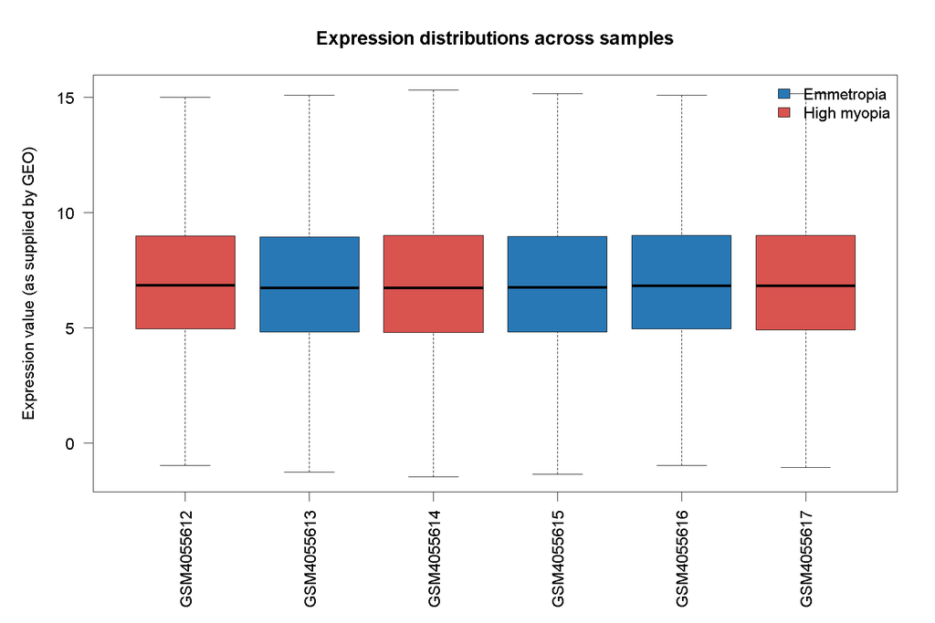

The six samples have broadly similar medians and spreads. This does not establish that every sample is free from technical artefacts. Hiding outlier symbols in the boxplot does not remove observations from the analysis.

## 5.2 Principal component analysis

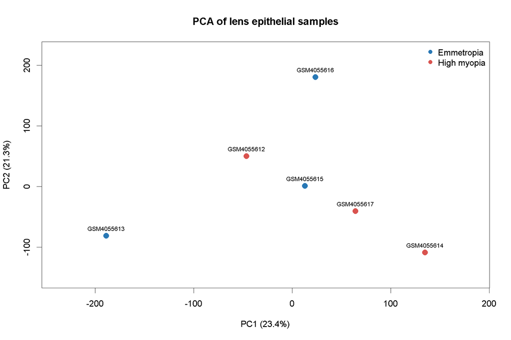

PCA uses all probes, with centring but no scaling to unit variance. PC1 explains 23.40% and PC2 explains 21.26% of variation. Together they account for 44.65%. The first two components do not show clear separation by diagnosis.

## 5.3 Sample clustering

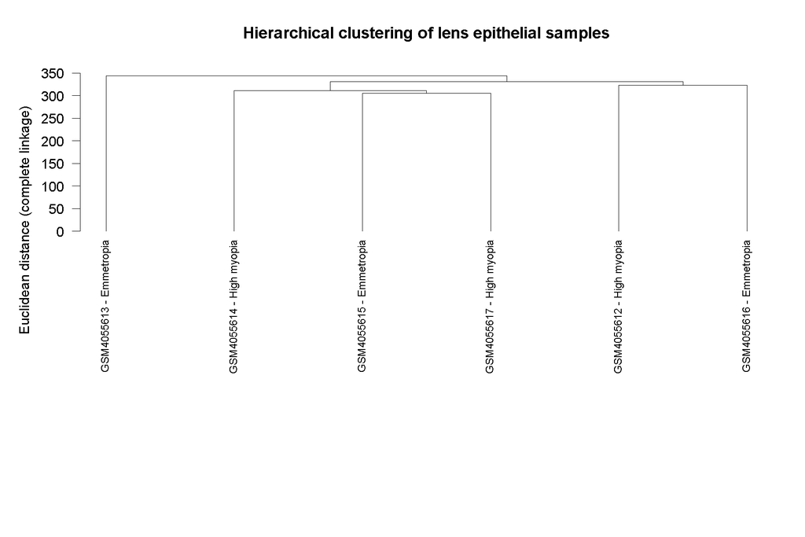

Euclidean distance and complete linkage produce mixed diagnostic groups. No sample is excluded solely because of its position in this exploratory tree.

# 6 Differential expression analysis

The limma model compares High myopia minus Emmetropia, with diagnosis as its only predictor. Positive effects indicate higher expression in high myopia. Empirical Bayes moderation is followed by Benjamini–Hochberg adjustment across the probes. The selection rule is adjusted p-value below 0.05. Age and gender are not adjusted.

```r
run_script("code/04_differential_expression.R")
```

```
##            Emmetropia HighMyopia
## GSM4055612          0          1
## GSM4055613          1          0
## GSM4055614          0          1
## GSM4055615          1          0
## GSM4055616          1          0
## GSM4055617          0          1
## attr(,"assign")
## [1] 1 1
## attr(,"contrasts")
## attr(,"contrasts")$group
## [1] "contr.treatment"
##
##
## Probes tested: 54675
## Probes with adjusted p < 0.05: 0
##                Probe_ID Expression_Difference  AveExpr         t      P.Value
## 217306_at     217306_at             -4.168130 1.986873 -18.12406 3.706455e-06
## 239791_at     239791_at             -2.804656 3.766917 -12.91015 2.349880e-05
## 217394_at     217394_at              3.460349 2.753460  12.77509 2.487218e-05
## 222274_at     222274_at              3.033032 4.364779  11.94689 3.569203e-05
## 220842_at     220842_at              4.015700 4.407495  11.92507 3.604459e-05
## 232572_at     232572_at              2.841560 4.231956  11.83066 3.761796e-05
## 243788_at     243788_at             -2.457444 4.136178 -11.52204 4.335414e-05
## 240178_at     240178_at             -3.429813 4.137563 -11.45099 4.481657e-05
## 228137_s_at 228137_s_at             -2.688699 4.175398 -11.40688 4.575344e-05
## 206863_x_at 206863_x_at              3.301160 4.348993  11.38367 4.625585e-05
##             adj.P.Val        B
## 217306_at   0.2008821 1.837792
## 239791_at   0.2008821 1.379109
## 217394_at   0.2008821 1.360995
## 222274_at   0.2008821 1.239441
## 220842_at   0.2008821 1.235976
## 232572_at   0.2008821 1.220816
## 243788_at   0.2008821 1.169297
## 240178_at   0.2008821 1.156994
## 228137_s_at 0.2008821 1.149271
## 206863_x_at 0.2008821 1.145179
```

```r
n_significant <- sum(results$adj.P.Val < 0.05, na.rm = TRUE)
knitr::kable(data.frame(
  Measure = c("Probes tested", "Adjusted p < 0.05", "Minimum adjusted p"),
  Value = c(nrow(results), n_significant, min(results$adj.P.Val, na.rm = TRUE))
), caption = "Differential analysis summary")
```

Differential analysis summary

| Measure | Value |
| --- | --- |
| Probes tested | 5.467500e+04 |
| Adjusted p < 0.05 | 0.000000e+00 |
| Minimum adjusted p | 2.008821e-01 |

```r
knitr::kable(head(results, 10), digits = 6,
             caption = "Top-ranked probes; ranking does not imply significance")
```

Top-ranked probes; ranking does not imply significance

|  | Probe_ID | Expression_Difference | AveExpr | t | P.Value | adj.P.Val | B |
| --- | --- | --- | --- | --- | --- | --- | --- |
| 217306_at | 217306_at | -4.168130 | 1.986873 | -18.12406 | 4.0e-06 | 0.200882 | 1.837792 |
| 239791_at | 239791_at | -2.804656 | 3.766918 | -12.91015 | 2.3e-05 | 0.200882 | 1.379109 |
| 217394_at | 217394_at | 3.460349 | 2.753460 | 12.77509 | 2.5e-05 | 0.200882 | 1.360995 |
| 222274_at | 222274_at | 3.033032 | 4.364779 | 11.94689 | 3.6e-05 | 0.200882 | 1.239441 |
| 220842_at | 220842_at | 4.015700 | 4.407495 | 11.92507 | 3.6e-05 | 0.200882 | 1.235976 |
| 232572_at | 232572_at | 2.841560 | 4.231956 | 11.83066 | 3.8e-05 | 0.200882 | 1.220816 |
| 243788_at | 243788_at | -2.457444 | 4.136178 | -11.52204 | 4.3e-05 | 0.200882 | 1.169297 |
| 240178_at | 240178_at | -3.429813 | 4.137563 | -11.45099 | 4.5e-05 | 0.200882 | 1.156994 |
| 228137_s_at | 228137_s_at | -2.688699 | 4.175398 | -11.40689 | 4.6e-05 | 0.200882 | 1.149271 |
| 206863_x_at | 206863_x_at | 3.301160 | 4.348993 | 11.38367 | 4.6e-05 | 0.200882 | 1.145179 |

The model identifies **0 probes** at adjusted p < 0.05. The smallest adjusted p-value is 0.2009. The observed zero-significant-probe result does not prove biological equivalence. The significant-probes CSV is expected to contain only headers when no probes pass the threshold.

# 7 Results visualisation

```r
run_script("code/05_results_visualisation.R")
```

## 7.1 Expression differences and statistical evidence

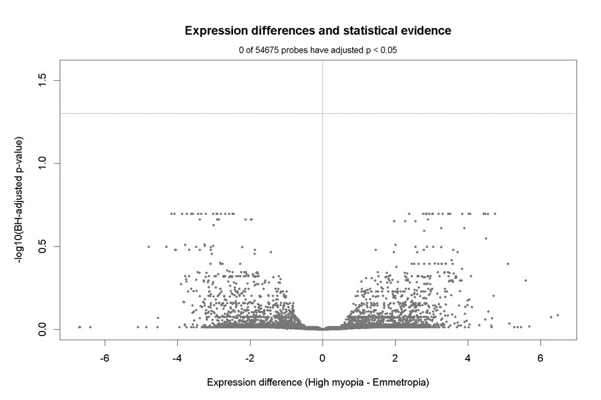

The horizontal axis is the estimated expression difference. The vertical axis is negative log10 adjusted p-value. All points in the observed result fall below the 0.05 threshold line. Horizontal bands can occur when probes share adjusted p-values.

## 7.2 Exploratory top-30 heatmap

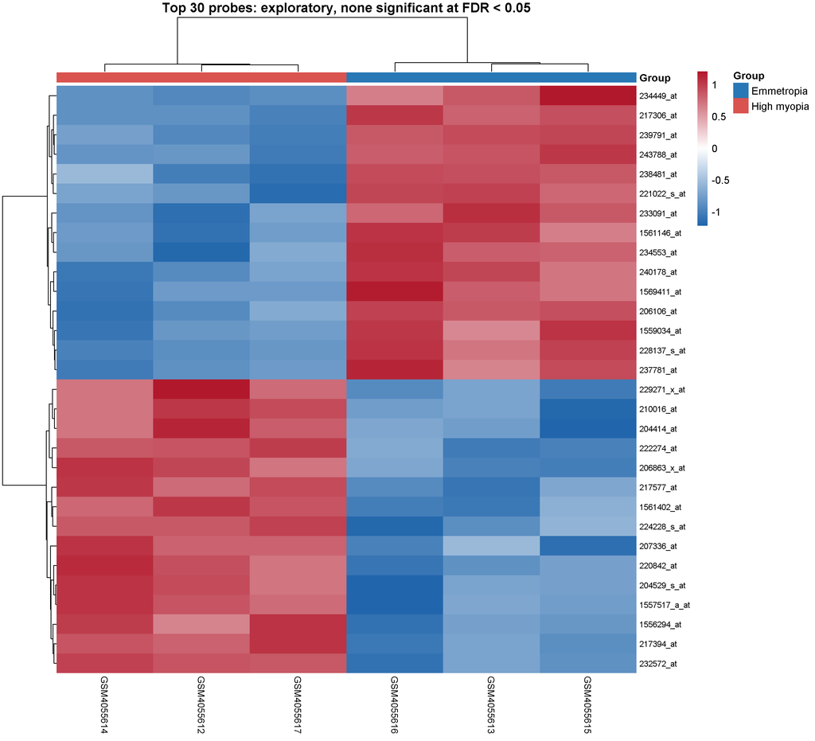

These probes were selected by the smallest unadjusted p-values in the same group comparison. Their apparent separation of diagnoses is therefore not independent validation. None passed the adjusted threshold in this analysis. Colours show row z-scores: red is above a probe’s own average and blue is below it. They do not compare absolute expression across different probes.